# Clustering

### Applications:

- Recommendor Systems
- Grouping similar people
- Data Compression

### K-Means:

Random points are chosen and clusters of nearest points are made.

```python
import matplotlib.pyplot as plt
from sklearn import datasets
from sklearn.cluster import KMeans

iris = datasets.load_iris()
X = iris.data[:, :2]
y = iris.target

model = KMeans(n_clusters=3)
model.fit(X)
labels = model.predict(X)
```

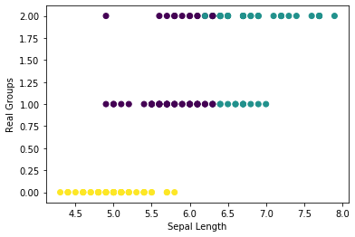

```python
plt.scatter(x = X[:,0], y = y, c = labels)
plt.xlabel('Sepal Length')
plt.ylabel('Real Groups')
plt.show()
```

### Visualizing Clusters

Agglomerative Hierarchy clustering: Every point has it's own cluster, at each step 2 closest clusters are merged. Visualize with dendogram tree.

### Evaluating a Cluster

Compare clustering to real flower label. Cross tabulation tables.

For unlabeled data, look at how spreak out the clusters are. Distance from each sample to centroid of its cluster. This is the Inertia measure. More clusters has lower inertia, but can have too many clusters. Choose a cluster number with high marginal change.

```
<function matplotlib.pyplot.show(*args, **kw)>
```

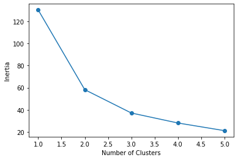

```python
ks = range(1,6)
inertias = []
for k in ks:
  model = KMeans(n_clusters= k)
  model.fit(X)
  inertias.append(model.inertia_)

plt.plot(ks, inertias, '-o')
plt.xlabel("Number of Clusters")
plt.ylabel("Inertia")
plt.show
```

### Transforming with Clusters

Need to use StandardScaler to get equal variance. Much more accurate with StandardScaler

```
<function matplotlib.pyplot.show(*args, **kw)>
```

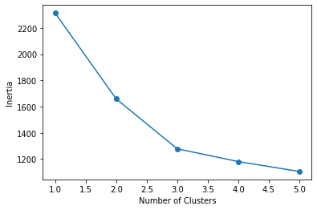

```python
from sklearn.preprocessing import StandardScaler
from sklearn.pipeline import make_pipeline

data_wine, target_wine = datasets.load_wine(return_X_y = True)

scale = StandardScaler()
newdata = scale.fit_transform(data_wine)

# pipeline = (make_pipeline, )

inertias = []
ks1 = range(1,6)

for k in ks1:
  model = KMeans(n_clusters= k)
  model.fit(newdata)
  inertias.append(model.inertia_)

plt.plot(ks, inertias, '-o')
plt.xlabel("Number of Clusters")
plt.ylabel("Inertia")
plt.show
```

## Hierarchical Clustering

Extract clusters from intermediate stage. Find intermediate clusters by defining a dendrogram height. This height is the max distance bewtween points. Distance is defined by linkage method ("complete").

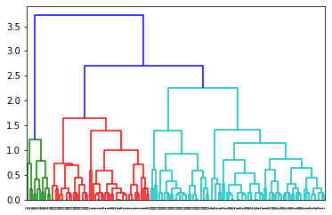

```python
from scipy.cluster.hierarchy import linkage, dendrogram
mergings = linkage(X, method = 'complete')
dendrogram(mergings, labels = y)
plt.show()
```

## DBScan

Specify how close things have to be and minimum points in a cluster. Don't need to define the number of clusters

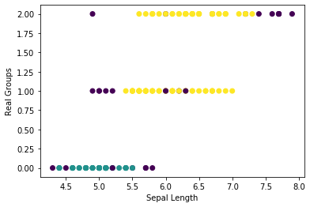

```python
from sklearn.cluster import DBSCAN
iris = datasets.load_iris()
X = iris.data[:, :2]
y = iris.target

db = DBSCAN(eps = 0.3, min_samples = 10)
db.fit(X)
labels = db.labels_

plt.scatter(x = X[:,0], y = y, c = labels)
plt.xlabel('Sepal Length')
plt.ylabel('Real Groups')
plt.show()
```

### t-SNE

Maps samples to 2D space (or 3D). map approximately nearest samples. Only has fit_transform(), cannot be extended to include new samples. Try learning rates between 50-200, too many and all points will be at the same point.

```python
from sklearn.manifold import TSNE
model = TSNE(learning_rate = .01)
```